```python
from IPython.display import display, Image
```

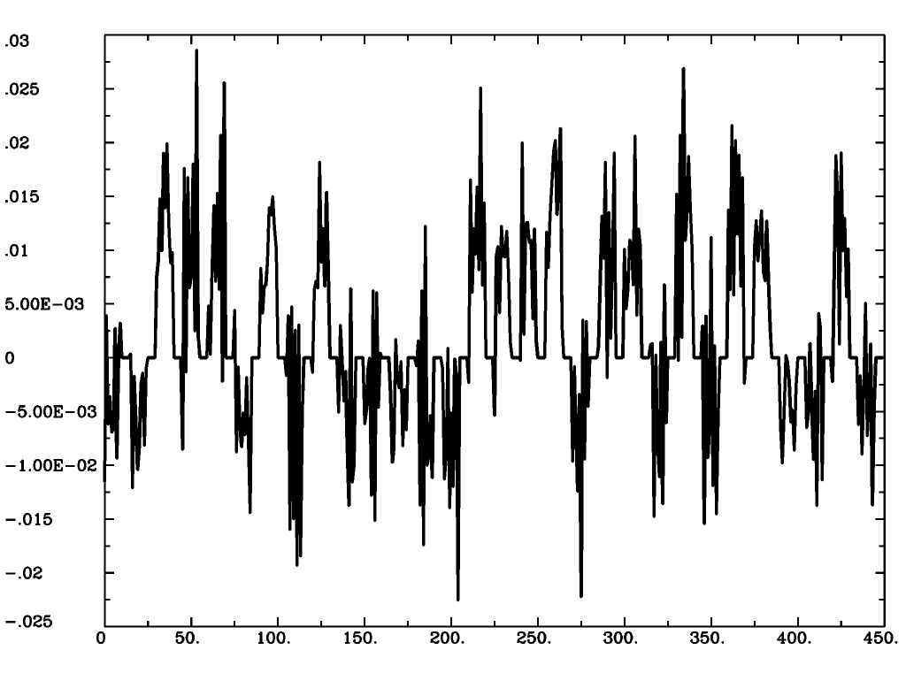

```python
display(Image(filename = '1d.jpg'))
```

# 1D Time Series

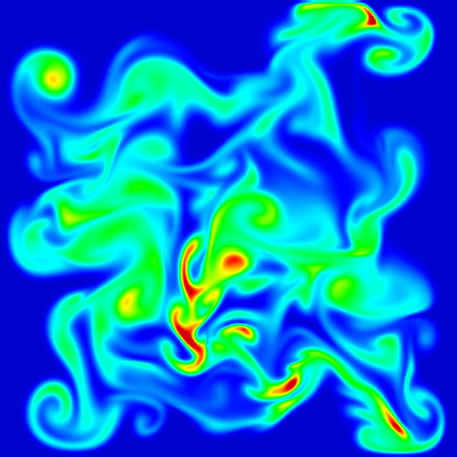

```python
display(Image(filename = '2dscalar.jpg'))
```

# 2D Scalar

Scalars are used to describe one dimensional quantities, that is, quantities which require only one number to completely describe them. In this case, the 2D scalar of this graph is taking in random points of smoke.

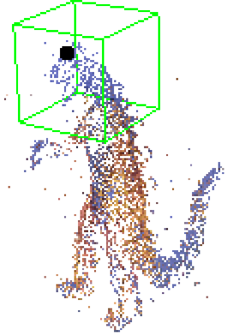

```python
display(Image(filename = '3dscalar.png'))
```

# 3D Scalar

Scalars are used to describe one dimensional quantities, that is, quantities which require only one number to completely describe them. For this scalar we get an object of a dinosaur being shown.

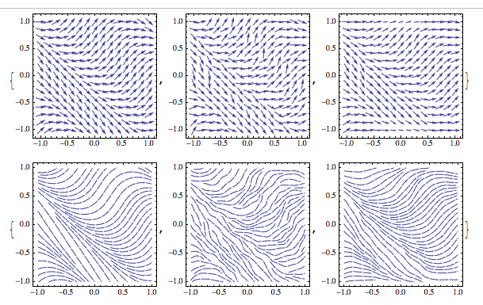

```python
display(Image(filename = '2dvector.png'))
```

# 2D Vector

Vectors are used to describe multi-dimensional quantities. Multi-dimensional quantities are those which require more than one number to completely describe them. Vectors, unlike scalars, have two characteristics, magnitude and direction. In this case, we are seeing the different wind changes and the direction.

[figure not shown]

```python
display(Image(filename = '3dshape.jpg'))
```

# 3D - Shape

This is a 3D shape of two animals( cat and lion). 3D shapes usually focus on showing how an object is represented.

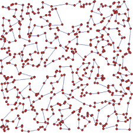

```python
display(Image(filename = 'graph.png'))
```

# Graph (not tree)

This is a graph of the Traveling Salesman Problem represented.